# Punto 2 - Apriori - cesta de compras

1. Los parametros que puedo modificar del algoritmo de Aprori son:
- support: soporte minimo que debe tener una transaccion para estar en el resultado, proporcion de la cantidad de veces que aparece.
- confidence: proportcion de cuantas veces se da que dada LHS se encuentre RHS
- target: que busca el algoritmo, puede ser itemset frecuentes, reglas de asociacion u otros
- minlen/maxlen: minimo o maximo numero de item set
- maxtime: limite de tiempo para chequear subsets entre otros

```r
librerias_instaladas<-rownames(installed.packages())
if("arules" %in% librerias_instaladas == FALSE) {
  install.packages("arules", dependencies = TRUE)
}
librerias_instaladas<-rownames(installed.packages())
if("arulesviz" %in% librerias_instaladas == FALSE) {
  install.packages("arulesViz", dependencies = TRUE)
}
```

```
Error in install.packages : Updating loaded packages
```

```r
library(arules)
library(arulesViz)
```

```r
data("Groceries")
```

```r
reglas <- apriori(Groceries, parameter = list(support=0.01, confidence=0.01,target = "rules"))
```

```
Apriori

Parameter specification:
```

|  | confidence | minval | smax | arem | aval | originalSupport | maxtime | support | minlen | maxlen | target | ext |
| --- | --- | --- | --- | --- | --- | --- | --- | --- | --- | --- | --- | --- |
|  | 0.01 | 0.1 | 1 | none | FALSE | TRUE | 5 | 0.01 | 1 | 10 | rules | TRUE |

```
Algorithmic control:
```

|  | filter | tree | heap | memopt | load | sort | verbose |
| --- | --- | --- | --- | --- | --- | --- | --- |
|  | 0.1 | TRUE | TRUE | FALSE | TRUE | 2 | TRUE |

```
Absolute minimum support count: 98

set item appearances ...[0 item(s)] done [0.00s].
set transactions ...[169 item(s), 9835 transaction(s)] done [0.00s].
sorting and recoding items ... [88 item(s)] done [0.00s].
creating transaction tree ... done [0.00s].
checking subsets of size 1 2 3 4 done [0.00s].
writing ... [610 rule(s)] done [0.00s].
creating S4 object  ... done [0.00s].
```

2. es posible ejecutar el algoritmo sobre los datos sin hacer ninguna operacion
3. Para encontrar las mejores reglas se recomienza usar LIFT ya que nos indica la una proporcion entre la confianza de la regla y la confiaza esperada, esto nos permite saber si ambas partes de una regla son estadisticamente independientes. Ordenando el resultado por el Lift vemos las siguientes reglas:

```r
inspect(sort(reglas, by="lift", decreasing = TRUE))
```

|  | lhs |  | rhs | support | confidence | coverage | lift | count |
| --- | --- | --- | --- | --- | --- | --- | --- | --- |
| [1] | {whole milk,yogurt} | => | {curd} | 0.01006609 | 0.17967332 | 0.05602440 | 3.3723037 | 99 |
| [2] | {citrus fruit,other vegetables} | => | {root vegetables} | 0.01037112 | 0.35915493 | 0.02887646 | 3.2950455 | 102 |
| [3] | {other vegetables,yogurt} | => | {whipped/sour cream} | 0.01016777 | 0.23419204 | 0.04341637 | 3.2670620 | 100 |
| [4] | {tropical fruit,other vegetables} | => | {root vegetables} | 0.01230300 | 0.34277620 | 0.03589222 | 3.1447798 | 121 |
| [5] | {root vegetables} | => | {beef} | 0.01738688 | 0.15951493 | 0.10899847 | 3.0403668 | 171 |
| [6] | {beef} | => | {root vegetables} | 0.01738688 | 0.33139535 | 0.05246568 | 3.0403668 | 171 |
| [7] | {citrus fruit,root vegetables} | => | {other vegetables} | 0.01037112 | 0.58620690 | 0.01769192 | 3.0296084 | 102 |
| [8] | {tropical fruit,root vegetables} | => | {other vegetables} | 0.01230300 | 0.58454106 | 0.02104728 | 3.0209991 | 121 |
| [9] | {other vegetables,whole milk} | => | {root vegetables} | 0.02318251 | 0.30978261 | 0.07483477 | 2.8420820 | 228 |
| [10] | {other vegetables,whole milk} | => | {butter} | 0.01148958 | 0.15353261 | 0.07483477 | 2.7706297 | 113 |

[output cut: 600 more lines]

C-bis) Se puede observar como la regla {whole milk,yogurt} => {curd} es la mejor usando LIFT por mas que tenga un support y confidence bajo. Hay algunos casos en los que entiendo que es comun que se lleven varias cosas juntas o no se lleve, puede ser? pienso esto con el caso de: {root vegetables} => {beef} {beef} => {root vegetables} es como 2 cosas q es muy probable que encuentes juntas, ya q una implica la otra y al reves.

4. Aunque el algoritmo se ejecuto muy rapido, entiendo que el algoritmo es “computacionalmente pesado” por lo que dependiendo el objetivo se pueden realizar varios tipos de podas como:
- aumentar el soporte minimo para encontrar reglas que se repiten mucho
- aumentar la confianza minima para reglas que tengan mucha implicancia
- min/max len para seleccionar solo itemset con mayor o menor cantidad de items que algun X (limpiar itemssets con 1 solo item o con demaciados muchos)
5. Siendo todos alimentos se me dificulta encontrar alguna relacion interesante, la mas llamativa es la que nombre en C-bis de {beef} => {root vegetables}, siendo que esta se da bastante, se podria hacer un AB testing en distintos locales y validar si ponerlos cerca aumenta la compras de los mismo o si al ponerlos separados (total la gente los va a buscar igual) y entre medio agregar otros productos, que tiene un confianza alta y en la pre-condicion tiene beef o root vegetables, se aumenta la venta de estos otros productos.
6. En el grafico se puede observar que varias de las reglas que tienen alto soporte tiene un bajo lift y bajo confianza. tambien se ve que la mayoria de las reglas estan entre un lift de 1(estadisticamente indepenientes) y un lift de 2. pocas son las que tiene un lift superior a 3 las cuales serian las mas interesantes.

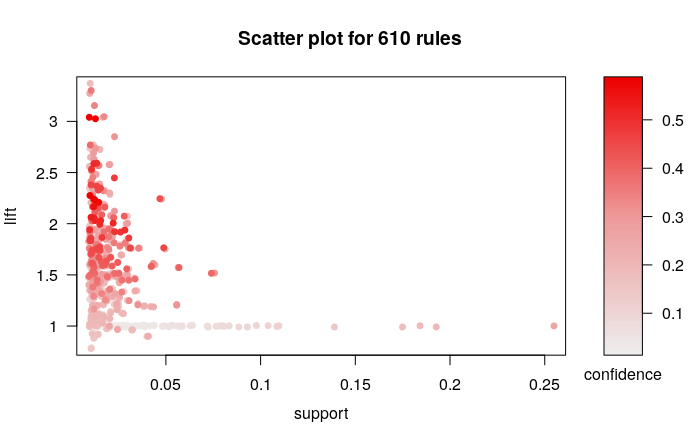

```r
plot(reglas, measure = c("support", "lift"), shading = "confidence")
```

```r
reglas_beer <- apriori(Groceries, parameter = list(support=0.01, confidence=0.01, target = "rules", minlen=2), appearance = list(lhs="bottled beer"))
```

```
Apriori

Parameter specification:
```

|  | confidence | minval | smax | arem | aval | originalSupport | maxtime | support | minlen | maxlen | target | ext |
| --- | --- | --- | --- | --- | --- | --- | --- | --- | --- | --- | --- | --- |
|  | 0.01 | 0.1 | 1 | none | FALSE | TRUE | 5 | 0.01 | 2 | 10 | rules | TRUE |

```
Algorithmic control:
```

|  | filter | tree | heap | memopt | load | sort | verbose |
| --- | --- | --- | --- | --- | --- | --- | --- |
|  | 0.1 | TRUE | TRUE | FALSE | TRUE | 2 | TRUE |

```
Absolute minimum support count: 98

set item appearances ...[1 item(s)] done [0.00s].
set transactions ...[169 item(s), 9835 transaction(s)] done [0.00s].
sorting and recoding items ... [88 item(s)] done [0.00s].
creating transaction tree ... done [0.00s].
checking subsets of size 1 2 done [0.00s].
writing ... [5 rule(s)] done [0.00s].
creating S4 object  ... done [0.00s].
```

```r
inspect(reglas_beer)
```

|  | lhs |  | rhs | support | confidence | coverage | lift | count |
| --- | --- | --- | --- | --- | --- | --- | --- | --- |
| [1] | {bottled beer} | => | {bottled water} | 0.01576004 | 0.1957071 | 0.08052872 | 1.7707259 | 155 |
| [2] | {bottled beer} | => | {soda} | 0.01698017 | 0.2108586 | 0.08052872 | 1.2092094 | 167 |
| [3] | {bottled beer} | => | {rolls/buns} | 0.01362481 | 0.1691919 | 0.08052872 | 0.9198466 | 134 |
| [4] | {bottled beer} | => | {other vegetables} | 0.01616675 | 0.2007576 | 0.08052872 | 1.0375464 | 159 |
| [5] | {bottled beer} | => | {whole milk} | 0.02043721 | 0.2537879 | 0.08052872 | 0.9932367 | 201 |

```r
reglas_beer <- apriori(Groceries, parameter = list(support=0.01, confidence=0.01, target = "rules", minlen=2), appearance = list(rhs="bottled beer"))
```

```
Apriori

Parameter specification:
```

|  | confidence | minval | smax | arem | aval | originalSupport | maxtime | support | minlen | maxlen | target | ext |
| --- | --- | --- | --- | --- | --- | --- | --- | --- | --- | --- | --- | --- |
|  | 0.01 | 0.1 | 1 | none | FALSE | TRUE | 5 | 0.01 | 2 | 10 | rules | TRUE |

```
Algorithmic control:
```

|  | filter | tree | heap | memopt | load | sort | verbose |
| --- | --- | --- | --- | --- | --- | --- | --- |
|  | 0.1 | TRUE | TRUE | FALSE | TRUE | 2 | TRUE |

```
Absolute minimum support count: 98

set item appearances ...[1 item(s)] done [0.00s].
set transactions ...[169 item(s), 9835 transaction(s)] done [0.00s].
sorting and recoding items ... [88 item(s)] done [0.00s].
creating transaction tree ... done [0.00s].
checking subsets of size 1 2 3 4 done [0.00s].
writing ... [5 rule(s)] done [0.00s].
creating S4 object  ... done [0.00s].
```

```r
inspect(reglas_beer)
```

|  | lhs |  | rhs | support | confidence | coverage | lift | count |
| --- | --- | --- | --- | --- | --- | --- | --- | --- |
| [1] | {bottled water} | => | {bottled beer} | 0.01576004 | 0.14259430 | 0.1105236 | 1.7707259 | 155 |
| [2] | {soda} | => | {bottled beer} | 0.01698017 | 0.09737609 | 0.1743772 | 1.2092094 | 167 |
| [3] | {rolls/buns} | => | {bottled beer} | 0.01362481 | 0.07407407 | 0.1839349 | 0.9198466 | 134 |
| [4] | {other vegetables} | => | {bottled beer} | 0.01616675 | 0.08355229 | 0.1934926 | 1.0375464 | 159 |
| [5] | {whole milk} | => | {bottled beer} | 0.02043721 | 0.07998408 | 0.2555160 | 0.9932367 | 201 |

7. la unica regla que tiene un lift minimamente alto como para resultar interesante es bottled water} => {bottled beer} pero creo q no aporta nada
8. Agregaria un tamaño minimo de itemsets, ya q no es interesante implicaciones del tipo {} -> {algo}, primero buscaria relaciones en las que varios elementos impliquen otro para ofrecer ofertas.

```r
ofertas <- apriori(Groceries, parameter = list(support=0.001, confidence=0.01,target = "rules", minlen= 4))
```

```
Apriori

Parameter specification:
```

|  | confidence | minval | smax | arem | aval | originalSupport | maxtime | support | minlen | maxlen | target | ext |
| --- | --- | --- | --- | --- | --- | --- | --- | --- | --- | --- | --- | --- |
|  | 0.01 | 0.1 | 1 | none | FALSE | TRUE | 5 | 0.001 | 4 | 10 | rules | TRUE |

```
Algorithmic control:
```

|  | filter | tree | heap | memopt | load | sort | verbose |
| --- | --- | --- | --- | --- | --- | --- | --- |
|  | 0.1 | TRUE | TRUE | FALSE | TRUE | 2 | TRUE |

```
Absolute minimum support count: 9

set item appearances ...[0 item(s)] done [0.00s].
set transactions ...[169 item(s), 9835 transaction(s)] done [0.00s].
sorting and recoding items ... [157 item(s)] done [0.00s].
creating transaction tree ... done [0.00s].
checking subsets of size 1 2 3 4 5 6 done [0.02s].
writing ... [14488 rule(s)] done [0.00s].
creating S4 object  ... done [0.00s].
```

```r
inspect(sort(ofertas, by="support", decreasing = TRUE))
```

|  | lhs |  | rhs | support | confidence | coverage | lift | count |
| --- | --- | --- | --- | --- | --- | --- | --- | --- |
| [1] | {root vegetables,other vegetables,yogurt} | => | {whole milk} | 0.007829181 | 0.6062992 | 0.012913066 | 2.3728423 | 77 |
| [2] | {root vegetables,whole milk,yogurt} | => | {other vegetables} | 0.007829181 | 0.5384615 | 0.014539908 | 2.7828530 | 77 |
| [3] | {root vegetables,other vegetables,whole milk} | => | {yogurt} | 0.007829181 | 0.3377193 | 0.023182511 | 2.4208960 | 77 |
| [4] | {other vegetables,whole milk,yogurt} | => | {root vegetables} | 0.007829181 | 0.3515982 | 0.022267412 | 3.2257165 | 77 |
| [5] | {tropical fruit,other vegetables,yogurt} | => | {whole milk} | 0.007625826 | 0.6198347 | 0.012302999 | 2.4258155 | 75 |
| [6] | {tropical fruit,whole milk,yogurt} | => | {other vegetables} | 0.007625826 | 0.5033557 | 0.015149975 | 2.6014206 | 75 |
| [7] | {tropical fruit,other vegetables,whole milk} | => | {yogurt} | 0.007625826 | 0.4464286 | 0.017081851 | 3.2001640 | 75 |
| [8] | {other vegetables,whole milk,yogurt} | => | {tropical fruit} | 0.007625826 | 0.3424658 | 0.022267412 | 3.2637119 | 75 |
| [9] | {tropical fruit,root vegetables,other vegetables} | => | {whole milk} | 0.007015760 | 0.5702479 | 0.012302999 | 2.2317503 | 69 |
| [10] | {tropical fruit,root vegetables,whole milk} | => | {other vegetables} | 0.007015760 | 0.5847458 | 0.011997966 | 3.0220571 | 69 |

[output cut: 990 more lines]

Para ver posibles ofertas tuve que bajar el soporte minimo ya que no habia itemsets de mas de 3 items con soporte mayor que 0.01. Tambien los ordene por soporte y voy mirando a mano el lift. en estos casos veo que es comun la compra en general de vegetales, leche, yogur y frutas, son 4 items que en general parecen ir juntos.

```r
frecuentes <- apriori(Groceries, parameter = list(support=0.05, confidence=0.01,target = "rules", minlen= 2))
```

```
Apriori

Parameter specification:
```

|  | confidence | minval | smax | arem | aval | originalSupport | maxtime | support | minlen | maxlen | target | ext |
| --- | --- | --- | --- | --- | --- | --- | --- | --- | --- | --- | --- | --- |
|  | 0.01 | 0.1 | 1 | none | FALSE | TRUE | 5 | 0.05 | 2 | 10 | rules | TRUE |

```
Algorithmic control:
```

|  | filter | tree | heap | memopt | load | sort | verbose |
| --- | --- | --- | --- | --- | --- | --- | --- |
|  | 0.1 | TRUE | TRUE | FALSE | TRUE | 2 | TRUE |

```
Absolute minimum support count: 491

set item appearances ...[0 item(s)] done [0.00s].
set transactions ...[169 item(s), 9835 transaction(s)] done [0.00s].
sorting and recoding items ... [28 item(s)] done [0.00s].
creating transaction tree ... done [0.00s].
checking subsets of size 1 2 done [0.00s].
writing ... [6 rule(s)] done [0.00s].
creating S4 object  ... done [0.00s].
```

```r
inspect(sort(frecuentes, by="support", decreasing = TRUE))
```

|  | lhs |  | rhs | support | confidence | coverage | lift | count |
| --- | --- | --- | --- | --- | --- | --- | --- | --- |
| [1] | {other vegetables} | => | {whole milk} | 0.07483477 | 0.3867578 | 0.1934926 | 1.513634 | 736 |
| [2] | {whole milk} | => | {other vegetables} | 0.07483477 | 0.2928770 | 0.2555160 | 1.513634 | 736 |
| [3] | {rolls/buns} | => | {whole milk} | 0.05663447 | 0.3079049 | 0.1839349 | 1.205032 | 557 |
| [4] | {whole milk} | => | {rolls/buns} | 0.05663447 | 0.2216474 | 0.2555160 | 1.205032 | 557 |
| [5] | {yogurt} | => | {whole milk} | 0.05602440 | 0.4016035 | 0.1395018 | 1.571735 | 551 |
| [6] | {whole milk} | => | {yogurt} | 0.05602440 | 0.2192598 | 0.2555160 | 1.571735 | 551 |

inspeccionando aquellos que tengan un support alto tampoco encuentro nada interesante

```r
confianza <- apriori(Groceries, parameter = list(support=0.01, confidence=0.05,target = "rules", minlen= 2))
```

```
Apriori

Parameter specification:
```

|  | confidence | minval | smax | arem | aval | originalSupport | maxtime | support | minlen | maxlen | target | ext |
| --- | --- | --- | --- | --- | --- | --- | --- | --- | --- | --- | --- | --- |
|  | 0.05 | 0.1 | 1 | none | FALSE | TRUE | 5 | 0.01 | 2 | 10 | rules | TRUE |

```
Algorithmic control:
```

|  | filter | tree | heap | memopt | load | sort | verbose |
| --- | --- | --- | --- | --- | --- | --- | --- |
|  | 0.1 | TRUE | TRUE | FALSE | TRUE | 2 | TRUE |

```
Absolute minimum support count: 98

set item appearances ...[0 item(s)] done [0.00s].
set transactions ...[169 item(s), 9835 transaction(s)] done [0.00s].
sorting and recoding items ... [88 item(s)] done [0.00s].
creating transaction tree ... done [0.00s].
checking subsets of size 1 2 3 4 done [0.00s].
writing ... [513 rule(s)] done [0.00s].
creating S4 object  ... done [0.00s].
```

```r
inspect(sort(confianza, by="confidence", decreasing = TRUE))
```

|  | lhs |  | rhs | support | confidence | coverage | lift | count |
| --- | --- | --- | --- | --- | --- | --- | --- | --- |
| [1] | {citrus fruit,root vegetables} | => | {other vegetables} | 0.01037112 | 0.58620690 | 0.01769192 | 3.0296084 | 102 |
| [2] | {tropical fruit,root vegetables} | => | {other vegetables} | 0.01230300 | 0.58454106 | 0.02104728 | 3.0209991 | 121 |
| [3] | {curd,yogurt} | => | {whole milk} | 0.01006609 | 0.58235294 | 0.01728521 | 2.2791250 | 99 |
| [4] | {other vegetables,butter} | => | {whole milk} | 0.01148958 | 0.57360406 | 0.02003050 | 2.2448850 | 113 |
| [5] | {tropical fruit,root vegetables} | => | {whole milk} | 0.01199797 | 0.57004831 | 0.02104728 | 2.2309690 | 118 |
| [6] | {root vegetables,yogurt} | => | {whole milk} | 0.01453991 | 0.56299213 | 0.02582613 | 2.2033536 | 143 |
| [7] | {other vegetables,domestic eggs} | => | {whole milk} | 0.01230300 | 0.55251142 | 0.02226741 | 2.1623358 | 121 |
| [8] | {yogurt,whipped/sour cream} | => | {whole milk} | 0.01087951 | 0.52450980 | 0.02074225 | 2.0527473 | 107 |
| [9] | {root vegetables,rolls/buns} | => | {whole milk} | 0.01270971 | 0.52301255 | 0.02430097 | 2.0468876 | 125 |
| [10] | {pip fruit,other vegetables} | => | {whole milk} | 0.01352313 | 0.51750973 | 0.02613116 | 2.0253514 | 133 |

[output cut: 503 more lines]

Mirando lo que tiene alta confianza vuelvo a encontrar el caso de varios lacteos juntos {curd,yogurt} => {whole milk} tambien tiene sentido las primeras 2 reglas pensando en personas q van a comprar frutas y verduras, se llevan de varios tipos.